# FP-Growth

## Discovering Patterns in the Russian Housing Market for Analysis and Prediction

### 3804ICT Assignment Part I | FP-Growth | Trimester 2, 2019

Joshua Russell (s5057545) | joshua.russell2@griffithuni.edu.au

Joshua Mitchell (s5055278) | joshua.mitchell4@griffithuni.edu.au

Hayden Flatley (s5088623) | hayden.flatley@griffithuni.edu.au

### 1. Introduction

#### 1.1. Aim

The aim of this investigation is to find interesting relationships among property and neighbourhood attribute values in the form of frequent patterns and strong association rules. Such relationships will allow us to discover intrinsic patterns in the housing market which will help us understand characteristics behind properties and the types of properties found within certain areas. Moreover, by analysing strong association rules we will be able to better understand the underlying relationships present within the housing market, and among properties and neighbourhoods within Russia. We will use the FP-Growth algorithm for the task of frequent pattern mining, and to assist in the process of association rule mining. We introduce the FP-Growth algorithm below.

#### 1.2. FP-Growth

The Frequent Pattern Growth (FP-Growth) algorithm is an algorithm used to efficiently mine frequent patterns from a dataset. Before discussing the algorithm in detail, we will introduce some of the general concepts from frequent pattern analysis and association rule mining. Firstly, a pattern in the context of our investigation is a set of attribute values that occur among various property entries in the Russian housing market dataset. We can refer to this set of attribute values as a characteristic-set, as it contains certain characteristics about properties and the neighbourhoods they are within. Formally, for a housing market dataset consisting of property entries described by $m$ attributes, a characteristic-set $s$ of a particular property entry would be defined as:

$$ s = \{x_1, x_2, x_3, ..., x_m \}$$

where each value $x$ represents a value corresponding to one of the $m$ attributes that describe a property entry. For example, if $M_1$ represented the `floor` attribute (i.e. the floor of the building the property is on), $M_2$ represented the `max_floor` attribute (i.e. the total number of floors in the building), $M_3$ represented the `sub_area` attribute (i.e. the name of the Russian district the property is within), and $M_m$ represented the `build_year` attribute (i.e. the year the property was built), then the characteristic-set $s$ of an apartment located on the third floor of a building with 10 floors, in the Russian district Perovo, built in the year 1980, would be represented as follows:

$$ s = \{ 3, 10, Perovo, ..., 1980\}$$

k-characteristic-sets are simply characteristic-sets that contain k attribute values (i.e. k characteristics). For example, $\{ 3, 10\}$ would be a 2-characteristic-set, and $\{ 3, 10, Perovo\}$ would be a 3-characteristic-set.

In frequent pattern analysis, we would like to find which characteristic-sets in a dataset are frequent. Such frequent patterns of characteristics would show us inherent regularities in the dataset. Moreover, they would represent intrinsic and implicit properties of the dataset and could be used in other data mining tasks, such as association analysis. To know whether a pattern is frequent of not, we will firstly define a metric that is used to capture the meaning of frequency among characteristic-sets within a dataset. This metric is known as *support*, and it represents the fraction of property entries within the dataset that contain a particular characteristic-set:

$$ support(s) = \frac{frequency (s)}{N}$$

where $s$ is a characteristic-set, $frequency(s)$ defines the number of property entry characteristic-sets that the characteristic-set $s$ is a subset of in the dataset, and $N$ is the total number of property entries in the dataset. We can appreciate that the range of the support metric is $[0,1]$, $0.0$ when a characteristic-set $s$ is a subset of zero property entry characteristic-sets, and $1.0$ when a characteristic-set $s$ is a subset of all property entry characteristic-sets. Therefore, we know that the higher the support of a characteristic-set, the more frequent the characteristic-set is within the dataset. A threshold is then defined to determine whether or not a characteristic-set is frequent. This threshold is known as the minimum support, or *min_sup*, threshold. Characteristic-sets with a support greater than or equal to this minimum support threshold are classified as being frequent patterns, whereas characteristic-sets with a support less than this minimum support threshold are classified as being infrequent patterns. For example, if we had a dataset consisting of 1000 property entries, then we could define our minimum support threshold to be $0.8$. Meaning that for a characteristic-set to be considered frequent within the dataset, then it would need to be a subset of 800 or more of the property entry characteristic-sets. We may find that a characteristic-set $\{ Perovo, 1980 \}$ occurs 900 times in the dataset. In this case, the support of the characteristic-set would be $\frac{900}{1000} = 0.9$, and since its support is greater than the minimum support threshold of $0.8$, we would classify the characteristic-set $\{ Perovo, 1980 \}$ as a frequent characteristic-set, or frequent pattern. Such a frequent pattern would tell us that the Russian district Perovo has many properties that were built in the year 1980, suggesting that the district may have older homes in comparison to others.

As stated previously, these frequent patterns can be used in other data mining tasks such as association analysis. The goal of association analysis is to discover relationships (i.e. associations) between attribute values within a dataset. These relationships are represented in the form of association rules, where, in the context of our study, an antecedent characteristic-set implies a consequent characteristic-set (i.e. $Antecedent \to Consequent$). For example, the association rule $\{ Perovo \} \to \{ 1980 \}$ would indicate that if a property is within the Russian district Perovo, then it is likely that the year in which the property was built is 1980. Association rule mining aims to find such association rules that are frequent and strong within the context of the dataset. To quantify the frequency, or usefulness, of an association rule, the *support* metric introduced earlier is used:

$$ support(r) = \frac{a \cup c}{N} $$

where $r$ is an association rule with antecedent characteristic-set $a$ and consequent characteristic-set $c$, and $N$ is the total number of property entries in the dataset. Then, to quantify the strength, or certainty, of an association rule, the *confidence* metric is used:

$$ confidence(r) = \frac{a \cup c}{a} $$

In association rule mining, we would like to find strong rules that are both useful and certain. Consequently, we define two thresholds, the minimum support threshold (*min_sup*) and the minimum confidence threshold (*min_conf*), to specify whether or not a given association rule is considered to be strong or not within the context of the dataset. If an association rule has a support greater than or equal to *min_sup*, and a confidence greater than or equal to *min_conf*, then the rule is considered to be a strong association rule, otherwise, it is not considered to be strong. These thresholds effectively tell us that found strong association rules occur frequently enough in the dataset to be considered useful, and that the certainty of observing the consequent given the antecedent is relatively high within the context of the dataset. In the domain of the Russian housing market, such strong association rules can be used to better understand the underlying relationships present within the housing market, and among properties and neighbourhoods within Russia.

```
                                             Example Housing Market Dataset

                                        |----------------|--------------------|
                                        | Property Entry | Characteristic Set |
                                        |----------------|--------------------|
                                        | P1             | {A, B, C}          |
                                        | P2             | {A, B, C, D}       |
                                        | P3             | {A, B, D}          |
                                        | P4             | {A, E}             |
                                        |----------------|--------------------|
```

To use the FP-Growth algorithm to mine frequent patterns in the above dataset, we must firstly define the minimum support threshold to use when determining whether a pattern is frequent. For this example, we will set the minimum support threshold to be `0.75`. Now, the first step in mining frequent patterns with the FP-Growth algorithm is to determine and order all frequent 1-characteristic-sets. We do this by scanning the dataset and counting for each 1-characteristic-set how many property entries it is a subset of. We can then take these occurrence frequencies and divide them by the total number of property entries in the dataset to determine the support of each 1-characteristic-set. Next, we can eliminate infrequent 1-characteristic-sets and order the frequent 1-characteristic-sets in descending order according to their support values.

```
                                        Ordered Frequent 1-Characteristic Sets

                                          |----------------------|---------|
                                          | 1-Characteristic Set | Support |
                                          |----------------------|---------|
                                          | {A}                  | 1.00    |
                                          | {B}                  | 0.75    |
                                          |----------------------|---------|
```

Once we have found and ordered the frequent 1-characteristic sets according to their support, we can begin to construct the FP-tree. This is done by considering each property entry in the dataset. For each property entry, we take the corresponding characteristic-set and remove all infrequent characteristics from it. We then order the remaining characteristics according to the descending order defined by the support of the frequent 1-characteristic sets. Once we have an ordered characteristics-set, we can then add a branch to the FP-tree, where each node of the branch represents one of the characteristics within the set and its corresponding frequency count (in the base case this would be one). If a property entry branch is added to the FP-tree and there exists another branch with a common prefix, then the frequency count of each node along the common prefix is incremented by one. This process is repeated for all property entries in the dataset to construct the FP-tree.

```
                                      FP-Tree of the Example Housing Market Dataset

                                                     |--------|
                                                     |  null  |
                                                     |--------|
                                                        /
                                                       /
                                                  |-------|
                                                  | A : 4 |
                                                  |-------|
                                                    /
                                                   /
                                              |-------|
                                              | B : 3 |
                                              |-------|
```

After constructing the FP-tree of the dataset, we can begin mining frequent patterns. This is done by considering each frequent 1-characteristc-set in ascending order of support (note that the final 1-characteristic-set, which would in turn be the most frequent 1-characteristic-set, is not considered in this process since all frequent patterns of that 1-characteristic set would be mined by mining the other 1-characteristic-sets). Thus, for each characteristic, we firstly determine which branches in the FP-tree that characteristic occurs in. Subsequently, we use the node occurrence count of the characteristic to determine how often the prefix of that branch occurs in the FP-tree. Lastly, we construct another FP-tree data structure known as the conditional FP-tree to determine which characteristics in combination with the current characteristic are frequent patterns within the dataset. We do this by considering the occurrence count of all branch nodes within the conditional FP-tree, and if the occurrence count of a characteristic node is greater than or equal to the defined minimum support frequency (i.e. the support multiplied by the number of property entries in the dataset), then the characteristic that node represents and the prefix of the branch the node is on are considered to be frequent patterns in combination with the current characteristic. This process is repeated for all but the most frequent 1-characteristic-set in the list of frequent 1-characteristic-sets.

[output not shown]

```
                                            Frequent Characteristic Sets

                                          |--------------------|---------|
                                          | Characteristic Set | Support |
                                          |--------------------|---------|
                                          | {A}                | 1.00    |
                                          | {B}                | 0.75    |
                                          | {A, B}             | 0.75    |
                                          |--------------------|---------|
```

Once the frequent characteristic-sets have been found, association rules for the dataset can be generated through a binary partitioning of the frequent characteristic-sets. We can then determine strong association rules by checking whether the support and confidence of such rules is above or equal to the minimum support and confidence thresholds.

In the investigation that follows we use the FP-Growth algorithm to mine frequent patterns and association rules for the Russian housing market dataset.

#### 1.3. References:

- Wang, C. (2019). *Mining Frequent Patterns I*. Lecture, Griffith University, Gold Coast.
- Wang, C. (2019). *Mining Frequent Patterns II*. Lecture, Griffith University, Gold Coast.

### 2. Preprocessing

Here we import library modules, load the Russian housing market datasets and preprocess the data for the task of frequent pattern and association rule mining with the FP-Growth algorithm.

```python
# Imports
import time
import warnings
import itertools
import pyfpgrowth
import numpy as np
import pandas as pd
import seaborn as sns
import matplotlib.pyplot as plt

from collections import Counter
from mlxtend.frequent_patterns import fpgrowth as mlxtend_fpgrowth
from mlxtend.preprocessing import TransactionEncoder as mlxtend_TransactionEncoder

# Notebook settings
warnings.filterwarnings("ignore")
```

```python
# Load the Russian Housing Market datasets into pandas DataFrames
df_test = pd.read_csv("Data/test.csv")
df_train = pd.read_csv("Data/train.csv")

# Add a 'price_doc' column to the test DataFrame filled with NaN values
df_test = df_test.assign(price_doc=pd.Series([np.nan for i in range(df_test.shape[0])]).values)

# Add an 'identifier' column to the test DataFrame filled with "TEST" string values
df_test = df_test.assign(identifier=pd.Series(["TEST" for i in range(df_test.shape[0])]).values)

# Add an 'identifier' column to the train DataFrame filled with "TRAIN" string values
df_train = df_train.assign(identifier=pd.Series(["TRAIN" for i in range(df_train.shape[0])]).values)

# Concatenate test and train DataFrames
df = pd.concat([df_train, df_test], sort=False, ignore_index=True)

# Concatenate datasets (both training and testing data samples)
print("Complete dataset\n- No. data samples: {}\n- No. of attributes: {}".format(df.shape[0], df.shape[1]))
```

```
Complete dataset
- No. data samples: 38133
- No. of attributes: 293
```

```python
# Define the property and neighbourhood attributes that will be used for frequent pattern and association rule mining
attributes = ["state", "full_sq", "life_sq", "floor", "ecology", "material", "max_floor", "build_year", "product_type",
              "nuclear_reactor_raion", "thermal_power_plant_raion", "incineration_raion", "oil_chemistry_raion",
              "radiation_raion", "railroad_terminal_raion", "big_market_raion", "detention_facility_raion", "railroad_1line",
              "sub_area"]
```

#### 2.1. Data Cleaning

Preprocessing steps for cleaning noisy data values are taken from our *Part 1: Data Investigation Notebook*.

```python
# Set the properties with `floor` or `max_floor` as null to have values of 1 for `floor` / `max_floor`
df.loc[df.floor.isnull(), 'floor'] = 1
df.loc[df.floor.isnull(), 'max_floor'] = 1

# Set the properties with `floor` greater than `max_floor` to have a `max_floor` equal to that of `floor`
df.loc[(df['floor'] > df['max_floor']), 'max_floor'] = df.loc[(df['floor'] > df['max_floor']), 'floor']

# Drop the data sample with a `state` value of 33
df = df.drop(df[(df.state > 4)].index)

# Set `full_sq` to be equal to `life_sq` in the cases where life_sq > full_sq
df.loc[(df.life_sq > df.full_sq), 'full_sq'] = df[(df.life_sq > df.full_sq)]["life_sq"]

# Drop the data samples with `build year` greater than 2019 or less than 1000
df = df.drop(df[(df.build_year > 2019) | (df.build_year < 1000)].index)

# Drop the remaining data samples that contain NaN values for any of the chosen attributes
df = df.dropna(subset=attributes)

# Display the dataset size after preprocessing
print("Preprocessed dataset\n- No. data samples: {}\n- No. of attributes: {}".format(df.shape[0], df.shape[1]))
```

```
Preprocessed dataset
- No. data samples: 19898
- No. of attributes: 293
```

#### 2.2. Data Transformation and Data Discretization

Here we define a class for discretizing attribute values into values that are compatible with the FP-Growth library functions and our own.

```python
class TransactionEncoder:
    """ Class for encoding the transactions (i.e. property entry characteristic-sets) into a format compatible with
        the manual solution."""

    def __init__(self):
        """ Initialises class variables for the TransactionEncoder Class.

        :var tidMap: A list of strings containing the names of each new attribute class.
        :var attributeRange: A dictionary mapping attribute names to an integer representing the number of new
                             attribute classes.
        :var attribSplitType: A dictionary mapping attributes names to an integer representing the attribute split
                              type.
        :var attribStart: A dictionary mapping attribute names to an integer representing the index within the tidMap
                          class variable that the attribute's class names start at.
        """

        self.tidMap = []
        self.attributeRange = {}
        self.attribSplitType = {}
        self.attribStart = {}

    def addToTIDMap(self, name, df, splitType, interval):
        """ Creates discrete attribute classes for each attribute based upon its split type.

        Takes a new attribute, splits it into its discrete classes and gives a unique transaction ID to
        each discrete class.

        :param name: A string representing the name of the attribute.
        :param df: The sub-DataFrame of selected attributes to be preprocessed.
        :param splitType: An integer identifying how the attribute should be transformed (i.e. split).
                          - 0: Keeps current categorical values for the attribute.
                          - 1: Splits attribute into three intervals (i.e. low, medium, high).
                          - 2: Splits attribute into a specified number of intervals.
                          - 3: Special case for Boolean attributes. Transactions that are True for
                               the attribute are kept, and transactions that are False are removed.
                               Since a transaction stating {milk, not_eggs} would not make sense.
        :param interval: An integer specifying the number of intervals the attribute should be split into.
                         This is used for attributes with a split type of 2.
        """

        # Return if no interval provided for split type 2
        if splitType == 2 and interval == None:
            print("No interval provided")
            return

        # Save attribute split information in class variables
        self.attribSplitType[name] = splitType
        self.attribStart[name] = len(self.tidMap)

        # Split type 0: attribute's categorical values become attribute's classes
        if splitType == 0:
            unqvals = df[name].unique()
            for u in unqvals:
                self.tidMap.append(name+'_'+str(u))
            self.attributeRange[name] = len(unqvals)

        # Split type 1: attribute's values split into classes (low, medium, high)
        elif splitType == 1:
            self.tidMap.append(name+'_Low')
            self.tidMap.append(name+'_Medium')
            self.tidMap.append(name+'_High')
            self.attributeRange[name] = 3

        # Split type 2: attribute's values split into n classes (where n is defined in intervals)
        elif splitType == 2:
            rng = df[name].max() - df[name].min()
            rngInt = rng/interval
            for i in range(0, int(rng), int(rngInt)):
                self.tidMap.append(name+'_'+str(df[name].min()+i)+'->'+str(df[name].min()+i+rngInt))
            self.attributeRange[name] = interval

        # Split type 3: attribute values are kept if Boolean value is True, thus attribute is split into one class
        elif splitType == 3:
            self.tidMap.append(name)
            self.attributeRange[name] = 1

    def createTIDMap(self, fpg_df, attrib, splitTypes, intervals):
        """ Creates a transaction ID for each attribute in the dataset.

        :param fpg_df: The sub-DataFrame of selected attributes to be preprocessed.
        :param attrib: A list of strings representing the names of the selected attributes in fpg_df.
        :param splitTypes: An list of integers identifying how the attribute should be transformed (i.e. split).
                           - 0: Keeps current categorical values for the attribute.
                           - 1: Splits attribute into three intervals (i.e. low, medium, high).
                           - 2: Splits attribute into a specified number of intervals.
                           - 3: Special case for Boolean attributes. Transactions that are True for
                               the attribute are kept, and transactions that are False are removed.
                               Since a transaction stating {milk, not_eggs} would not make sense.
        :param intervals: A list of integers specifying the number of intervals the attribute should be split into.
                          This is used for attributes with a split type of 2.
        """

        for a in range(len(attrib)):
            self.addToTIDMap(attrib[a], fpg_df, splitTypes[a], intervals[a])

    def discretizeRow(self, row, fpg_df):
        """ Discretizes a given row from the DataFrame.

        Takes in raw row data and for each attribute maps the continuous value to a discrete class.
        Boolean attributes will only include the transaction in the set if the value is true.

        :param row: A list containing the values for the given row of the DataFrame.
        :param fpg_df: The DataFrame of selected attributes to be discretized.
        :return: A list containing the discretized values for the given row.
        """

        discRow = []
        fpg_np = fpg_df.values.tolist()
        fpg_cols = fpg_df.columns.values

        # For each attribute in the given row, discretize according to the attribute's split type
        for c in range(len(row)):

            # Split type 0: attribute's categorical values become attribute's classes
            if self.attribSplitType[fpg_cols[c]] == 0:

                # Find out which unique categorical value it is
                unq = fpg_df[fpg_cols[c]].unique()
                for u in range(len(unq)):
                    if row[c] == unq[u]:
                        discRow.append(self.attribStart[fpg_cols[c]] + u)
                        break

            # Split type 1: attribute's values split into classes (low, medium, high)
            elif self.attribSplitType[fpg_cols[c]] == 1:

                # Calculate the interval range for the attribute (to be split into three classes)
                rng = fpg_df[fpg_cols[c]].max() - fpg_df[fpg_cols[c]].min()
                rngInt = rng / 3
                for i in range(3):
                    if row[c] >= fpg_df[fpg_cols[c]].min() + rngInt * i:
                        newID = self.attribStart[fpg_cols[c]] + i
                discRow.append(newID)

            # Split type 2: attribute's values split into n classes
            elif self.attribSplitType[fpg_cols[c]] == 2:

                # Calculate the interval range for the attribute (to be split into n classes)
                rng = fpg_df[fpg_cols[c]].max() - fpg_df[fpg_cols[c]].min()
                rngInt = rng / self.attributeRange[fpg_cols[c]]
                for i in range(self.attributeRange[fpg_cols[c]]):
                    if row[c] >= fpg_df[fpg_cols[c]].min() + rngInt * i:
                        newID = self.attribStart[fpg_cols[c]] + i + 1
                discRow.append(newID)

            # Split type 3: attribute values are kept if Boolean value is True, thus attribute is split into one class
            elif self.attribSplitType[fpg_cols[c]] == 3:

                # Only include boolean data in transactions if True
                if row[c] == 'yes':
                    discRow.append(self.attribStart[fpg_cols[c]])

        return discRow

    def discretize(self, fpg_df, numRows):
        """ Discretizes the specified number of rows in the given DataFrame.

        :param fpg_df: The DataFrame of selected attributes to be discretized.
        :param numRows: An integer specifying the number of rows (i.e. data samples) in the DataFrame to discretize.
        :return: A list containing the discretized rows of the DataFrame.
        """

        disc = []
        fpg_np = fpg_df.values.tolist()

        # Discretize numRows rows in the DataFrame one by one
        for r in range(numRows):
            disc.append(self.discretizeRow(fpg_np[r], fpg_df))

        return disc

    def decode(self, row):
        """ Decodes the given row from an integer representation back into the attribute class names.

        :param row: A list of integers representing the encoded labels of the discretized attribute class values.
        :return: A list of strings representing the names of the discretized attribute class values.
        """

        return [self.tidMap[r] for r in row]
```

#### 2.3. Dataset Preparation

We select the sub-dataframes which contain only the chosen attributes for our investigation and pre-process the data.

```python
# Lecture slides dataset for testing
testing = False
lecture_slides_transactions = [[1, 2, 5],
                               [2, 4],
                               [2, 3],
                               [1, 2, 4],
                               [1, 3],
                               [2, 3],
                               [1, 3],
                               [1, 2, 3, 5],
                               [1, 2, 3]]
```

```python
# Create a sub-DataFrame with the selected attributes
df_fpg = df[attributes]

# Define the split types (described in TransactionEncoder) and corresponding no. of intervals for each attribute
splitTypes = [0,1,1,1,0,0,1,2,0,3,3,3,3,3,3,3,3,3,0]
intervals = [-1,-1,-1,-1,-1,-1,-1,10,-1,-1,-1,-1,-1,-1,-1,-1,-1,-1,-1]

# Create a TransactionEncoder object to then encode the sub-DataFrame of attribute
encoder = TransactionEncoder()
encoder.createTIDMap(df_fpg, attributes, splitTypes, intervals)

# Discretize a specified number of rows in the sub-DataFrame
num_property_entries = 5000
property_entries = encoder.discretize(df_fpg, num_property_entries)
if testing:
    property_entries = lecture_slides_transactions

# Preprocess property entries for mlxtend format
mlxtend_te = mlxtend_TransactionEncoder()
mlxtend_encoded_array = mlxtend_te.fit(property_entries).transform(property_entries)
mlxtend_property_entries = pd.DataFrame(mlxtend_encoded_array, columns=mlxtend_te.columns_)
```

### 3. Library Solutions

We implement the FP-Growth algorithm using two Python libraries, Mlxtend (Machine Learning Extensions) and PyFPGrowth.

#### 3.1. Mlxtend (Machine Learning Extensions)

```python
def mlxtend_FPG(property_entries, min_sup_count):
    """ Mlxtend FP-Growth Implementation

    :param property_entries: A DataFrame containing preprocessed property entries to use for mining frequent patterns.
    :param min_sup_count: An integer specifying the minimum support count to use when mining frequent patterns.
    :return: A list of tuples representing the frequent patterns that were found.
    """

    # Convert minimum support count to minimum support
    min_sup = min_sup_count / len(property_entries)

    # Find all frequent patterns with a support greater than or equal to min_sup
    patterns = mlxtend_fpgrowth(property_entries, min_sup, use_colnames=True)

    # Return the frequent patterns that were found
    return patterns["itemsets"].values
```

#### 3.2. PyFPGrowth

```python
def pyfpgrowth_FPG(property_entries, min_sup_count):
    """ PyFPGrowth FP-Growth Implementation

    :param property_entries: An array containing preprocessed property entries to use for mining frequent patterns.
    :param min_sup_count: An integer specifying the minimum support count to use when mining frequent patterns.
    :return: A list of tuples representing the frequent patterns that were found.
    """

    # Find all frequent patterns with a support count greater than or equal to min_sup_count
    patterns = pyfpgrowth.find_frequent_patterns(property_entries, min_sup_count)

    # Return the frequent patterns that were found
    return list(patterns.keys())
```

### 4. Manual Solution

Here we manually implement the FP-Growth algorithm for frequent pattern mining.

```python
class Fp_Node:
    """ Class that represents a node within the FP Growth Tree.

    Args:
        children - list of children node for the current node
        item_id - the item index determined from the encoder class
        count - the support of the node
        parentNode - the parent of the node
        occurance_link - link to next occurance of the same item within the item_occurances
                        linked list (default : None)
    """

    def __init__(self, item_id, count, parentNode):
        self.children = []
        self.item_id = item_id
        self.count = count
        self.parentNode = parentNode
        self.occurance_link = None

    def add_child(self, item_id):
        """ Adds a new child to the nodes list of children.

        :return: The newly created child so that it may be placed in the item_occurance linked list.
        """

        child = Fp_Node(item_id, 1, self)
        self.children.append(child)
        return child

    def get_child_node(self, item_id):
        """ Checks each child of the node to see if the item passed in is one of its children.

        return: The child if it exists in the list of children, else None
        """
        for child in self.children:
            if child.item_id == item_id:
                return child
        return None

class Fp_Tree:
    """ Tree construction and frequent pattern mining portion of the FP Growth Algorithm.

    Attributes:
        transactions - the rows of transactions passed from the encoder class
        support_threshold - minimum support that items must reached so that they're considered frequent
        root_id - the root item index value. Null for overall tree, and index of suffix for conditional trees
        root_support - support count of root node. Zero for the overal tree, and support of suffix for
                        conditional trees.
    Properties:
        sortedTransactions - list of transactions where items are  sorted by their support count
        item_support_counts - counter dictionary of support counts for each item
        item_occurances - dictionary of linked lists connecting each occurance of an item so that
                            we may construct the conditional trees paths up to root from occurances.
        tree - the root node of either entire tree or each conditional tree.
    """

    def __init__(self, transactions, support_threshold, root_id=None, root_support=0):
        self.transactions = transactions
        self.support_threshold = support_threshold
        self.sortedTransactions = []
        self.item_support_counts = Counter()
        self.calculate_item_support()
        self.item_occurances = self.init_item_occurances()
        self.tree = Fp_Node(root_id, root_support, None)
        self.construct_tree()

    def calculate_item_support(self):
        """ Calculates the support of all items by increamenting counter the item is encountered.
            Each item is then checked to see if its support is greater than the minimum support threshold.
            If less, it's deleted from the item_support dicitonary and thus the tree.
        """
        # calculate support for each item
        for transaction in self.transactions:
            for item in transaction:
                self.item_support_counts[item] += 1

        # prune items that are below the support threshold
        for item in list(self.item_support_counts.keys()):
            if (self.item_support_counts[item] < self.support_threshold):
                del self.item_support_counts[item]

        self.sort_transactions()

    def sort_transactions(self):
        """ For each transaction, items are sorted by their support count. """

        for transaction in self.transactions:

            # Remove items from transactions that have been removed from item_support_counts
            self.sortedTransactions.append([item for item in transaction if item in self.item_support_counts])

            # Sort the transaction items by their support counts
            self.sortedTransactions[-1].sort(key=lambda item: self.item_support_counts[item], reverse=True)

    def get_sorted_items(self):
        """ Returns a sorted list of the items by their support count. """

        return sorted(self.item_support_counts.keys(), key=lambda item: self.item_support_counts[item])

    def construct_tree(self):
        """ Iterates through each row in the transaction database provided and adds each transaction to the tree. """

        for transaction in self.sortedTransactions:
            self.add_transaction(transaction)

    def init_item_occurances(self):
        """ Initialise all item_occurance linked lists to none so that the first occurance of the item is
            immediatley added to it corresponding linked list.

        :return: item_occurances - dictionary of linked lists with occurances of each item
        """

        item_occurances = {}
        for item in self.item_support_counts.keys():
            item_occurances[item] = None
        return item_occurances


    def add_transaction(self, transaction):
        """ Receive a list of items in the form of a transaction that are iterated through
            and added to the tree. Each item in the transaction is also added to its corresponding
            item_occurance linked list.

        :params: transaction - the list of items to be added to the tree (single row from database)
        """
        # Get root node
        node = self.tree
        for item in transaction:

            # Try to find the child in the current nodes children list
            child = node.get_child_node(item)
            if child == None:
                child = node.add_child(item)
            else:
                # increase path count at child node
                child.count += 1

            # If first encounter of item, add the child as the first item occurance
            if self.item_occurances[item] is None:
                self.item_occurances[item] = child
```

```python
            # If not first occurance then move through linked list to last occurance and add to link
            else:
                # iterate through item occurances and append new occurance to the end
                current = self.item_occurances[item]

                while current.occurance_link != None:
                    current = current.occurance_link

                current.occurance_link = child
                """
                    Because we don't create new children on subsequent item occurances we must set the
                    next occuance_link to none so we don't end up in an infinite loop.
                """
                child.occurance_link = None
            # move to the next node down in the tree, ready for next item in transaction
            node = child

    def tree_does_not_branch(self, root):
        """ For each node in the current tree, traverse tree in depth first search manner and check if
            any nodes have more than 1 child. If we reach the end of the tree then the tree is a straight path.

        :params: root - the root node of the tree, where we start descending from
        """

        no_children = len(root.children)
        node = root
        while (no_children != 0):
            if (no_children <= 1):
                return False
            node = node.children[0]
            no_children = len(node.children)
        return True

    def find_frequent_patterns(self):
        """ Determine if the tree is a single path with no branches. In which case the frequent patterns
            can be found by finding all combinations of items which have a support above the support threshold.
            This is the base case our algorithm. Otherwise we must continue moving up the item occurance table.
            When we reach the base case, the algorithm will return the patterns from traverse conditional trees
            at which point we append the item occurance to the path and again return.

        :return: patterns with the item suffixes appended
        """
        if self.tree_does_not_branch(self.tree):
            return self.straight_path()
        else:
            return self.append_item_suffix(self.traverse_conditional_trees())

    def append_item_suffix(self, patterns):
        """ Appends the item occurance to the prefix path pattern to return full frequent patterns.

        :params: patterns - the patterns returned from the straight_path function from the next level.
        """

        suffix = self.tree.item_id

        if suffix != None:
            appended_patterns = {}

            for key in patterns.keys():
                appended_patterns[tuple(sorted(list(key) + [suffix]))] = patterns[key]

            return appended_patterns

        return patterns

    def straight_path(self):
        """ We know that the current tree is a single straight path. So we can use all of the items and their
            support counts to find all subsets of the tree to return as frequent patterns.

        :return: patterns - all subsets of patterns for the tree
        """
        patterns = {}
        items = self.item_support_counts.keys()

        # If we are in a conditional tree,
        # the suffix is a pattern on its own.
        if self.tree.item_id is None:
            suffix_value = []
        else:
            suffix_value = [self.tree.item_id]
            patterns[tuple(suffix_value)] = self.tree.count

        # find all the subsets of items within the conditional trees' path
        for i in range(1, len(items) + 1):

            for subset in itertools.combinations(items, i):
                pattern = tuple(sorted(list(subset) + suffix_value))
                patterns[pattern] = min([self.item_support_counts[x] for x in subset])

        return patterns

    def print_tree(self, node):
        """ Recursively iterates though children in the tree printing the current node and their children

        :params: node - the current node witin the tree, starting with the root
        """

        print(f'node : {node.item_id} - Count({node.count}) - Parent({node.parentNode})')
        print("\tChildren : ", end='')
        for child in node.children:
            print(child.item_id, end=', ')
        print("\n")
        for child in node.children:
            self.print_tree(child)

    def traverse_conditional_trees(self):
        """ For the currently constructed tree, iterate through the each item in order of support until the
            conditional tree is a straight path, at which point the algorithm will return and append the item
            to the pattern

        :return: patterns - the frequent patterns found for the current tree
        """
        patterns = {}

        # iterate through items in ascending order of support
        for item in self.get_sorted_items():

            # list of item occurances to traverse to the root node
            suffixes = []
            conditional_tree_paths = []
            node = self.item_occurances[item]

            # continue adding item occurances until we reached the end of the linked list.
            while node != None:

                suffixes.append(node)
                node = node.occurance_link

            # Get the path of each item occurance
            for suffix in suffixes:
                support = suffix.count
                path = []

                # first item in path is parent of suffix
                parent = suffix.parentNode

                # move up to root node, adding each node along the way
                while parent.parentNode != None:
                    path.append(parent.item_id)
                    parent = parent.parentNode

                for i in range(support):
                    # add the path to the item occurance to the conditional tree for every path to item occurances
                    conditional_tree_paths.append(path)


            # create a conditional tree from all of the paths of the current item
            conditional_tree = Fp_Tree(conditional_tree_paths, self.support_threshold, item, self.item_support_counts[item])
            conditional_tree.construct_tree()
            conditional_tree_patterns = conditional_tree.find_frequent_patterns()
```

```python
            # Add conditional tree patterns to all patterns list
            for pattern in conditional_tree_patterns.keys():
                # Don't add already existing patterns
                if pattern in patterns:
                    patterns[pattern] += conditional_tree_patterns[pattern]
                else:
                    patterns[pattern] = conditional_tree_patterns[pattern]

        return patterns
```

```python
def manual_FPG(property_entries, min_sup_count):
    """ Manual Implementation of the FP-Growth Implementation

    :param property_entries: An array containing preprocessed property entries to use for mining frequent patterns.
    :param min_sup_count: An integer specifying the minimum support count to use when mining frequent patterns.
    :return: A list of tuples representing the frequent patterns that were found.
    """

    # Create an FP-Tree of the property entries
    tree = Fp_Tree(property_entries, min_sup_count)

    # Find all frequent patterns with a support count greater than or equal to min_sup_count
    patterns = tree.find_frequent_patterns()

    # Return the frequent patterns that were found
    return list(patterns.keys())
```

### 5. Results and Metrics

Within this section we provide experimental results on the Russian housing market dataset, compare the library implementations of the FP-Growth algorithm with our own, and present interesting frequent patterns that were found.

We briefly introduce the evaluation measures used when comparing the implementations below.

#### Support

To quantify the frequency, or usefulness, of a frequent pattern the support metric is used:

$$ support(s) = \frac{frequency(s)}{N}$$

where $s$ is a characteristic-set, $frequency(s)$ defines the number of property entry characteristic-sets that the characteristic-set $s$ is a subset of in the dataset, and $N$ is the total number of property entries in the dataset. We can appreciate that the range of the support metric is $[0.0,1.0]$, $0.0$ when a characteristic-set $s$ is a subset of zero property entry characteristic-sets, and $1.0$ when a characteristic-set $s$ is a subset of all property entry characteristic-sets. Therefore, we know that the higher the support of a characteristic-set, the more frequent the characteristic-set is within the dataset, and thus the more useful the discovered characteristic-set is. If the characteristic-set has a support that is greater than or equal to the minimum support threshold of the dataset (which is user defined), then the characteristic-set is called a frequent pattern.

When comparing the number of frequent patterns found by each implementation, we used the same minimum support threshold across each implementation (i.e. the two library implementations and our own).

#### Time Efficiency

Within this investigation, we define time efficiency as the total running time of the algorithm (i.e. the total time the FP-Growth algorithm takes to find all frequent patterns within the given dataset). Therefore, if an implementation of the algorithm takes a short amount of time to find all frequent patterns, then it is efficient. In contrast, if an implementation of the algorithm takes a long amount of time to find all frequent patterns, then it is inefficient. Simply, the faster the implementation the better.

#### 5.1. Number of Frequent Patterns Found

```python
# Specify the minimum support count to use for mining frequent patterns
min_sup_count = 4000

# Determine the number of frequent patterns found for each of the implementations
num_fp_found = []
implementation_names = []

# FP-Growth Manual Implementation
num_fp = len(manual_FPG(property_entries, min_sup_count))
num_fp_found.append(num_fp)
implementation_names.append("Manual ({})".format(num_fp))

# Mlxtend Implementation
num_fp = len(mlxtend_FPG(mlxtend_property_entries, min_sup_count))
num_fp_found.append(num_fp)
implementation_names.append("Mlxtend ({})".format(num_fp))

# PyFPGrowth Implementation
num_fp = len(pyfpgrowth_FPG(property_entries, min_sup_count))
num_fp_found.append(num_fp)
implementation_names.append("PyFPGrowth ({})".format(num_fp))

# Create DataFrame of the experimental data
experimental_data = {"ImplementationNames": implementation_names,
                     "No. FP": num_fp_found}
```

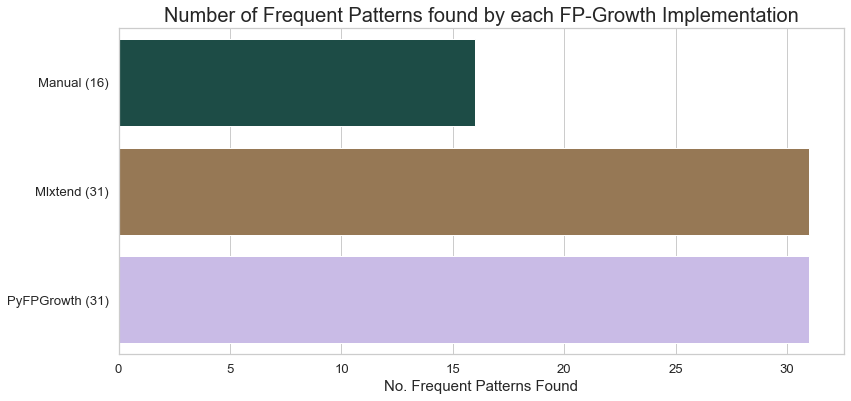

```python
# Display a bar plot of the number of frequent patterns found
sns.set(font_scale=1.2, style="whitegrid")
plt.figure(figsize=(13, 6))
ax = sns.barplot(x="No. FP", y="ImplementationNames", data=experimental_data, palette="cubehelix")
ax.set_title("Number of Frequent Patterns found by each FP-Growth Implementation", fontsize=20)
ax.set_xlabel("No. Frequent Patterns Found", fontsize=15)
plt.show()
```

#### 5.2. Time Efficiency of FP-Growth Implementations

```python
# Specify the minimum support count to use for mining frequent patterns
min_sup_count = 4000

# Determine the time efficiency (time to find all frequent patterns) of each of the implementations
durations = []
implementation_names = []

# FP-Growth Manual Implementation
start_time = time.clock()
_ = manual_FPG(property_entries, min_sup_count)
end_time = time.clock()
diff_time = end_time - start_time
durations.append(diff_time)
implementation_names.append("Manual ({:.4f}s)".format(diff_time))

# Mlxtend Implementation
start_time = time.clock()
_ = mlxtend_FPG(mlxtend_property_entries, min_sup_count)
end_time = time.clock()
diff_time = end_time - start_time
durations.append(diff_time)
implementation_names.append("Mlxtend ({:.4f}s)".format(diff_time))

# PyFPGrowth Implementation
start_time = time.clock()
_ = pyfpgrowth_FPG(property_entries, min_sup_count)
end_time = time.clock()
diff_time = end_time - start_time
durations.append(diff_time)
implementation_names.append("PyFPGrowth ({:.4f}s)".format(diff_time))

# Create DataFrame of the experimental data
experimental_data = {"ImplementationNames": implementation_names,
                     "Durations": durations}
```

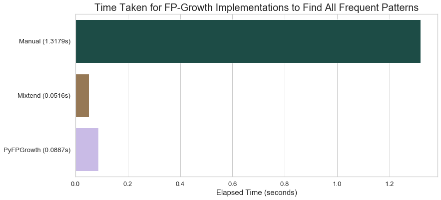

```python
# Display a bar plot of the time efficiencies
sns.set(font_scale=1.2, style="whitegrid")
plt.figure(figsize=(13, 6))
ax = sns.barplot(x="Durations", y="ImplementationNames", data=experimental_data, palette="cubehelix")
ax.set_title("Time Taken for FP-Growth Implementations to Find All Frequent Patterns", fontsize=20)
ax.set_xlabel("Elapsed Time (seconds)", fontsize=15)
plt.show()
```

#### 5.3. Interestingness of Found Frequent Patterns

```python
# Specify the minimum support count to use for mining frequent patterns
min_sup_count = 3000

# Find all frequent patterns with a support count greater than or equal to min_sup_count
frequent_patterns = mlxtend_FPG(mlxtend_property_entries, min_sup_count)

# Print frequent patterns
print("Frequent Patterns")
print("-----------------")
for pattern in frequent_patterns:
    print(encoder.decode(pattern))
```

```
Frequent Patterns
-----------------
['life_sq_Low']
['full_sq_Low']
['floor_Low']
['max_floor_Low']
['product_type_Investment']
['material_1.0']
['full_sq_Low', 'life_sq_Low']
['floor_Low', 'full_sq_Low']
['floor_Low', 'life_sq_Low']
['floor_Low', 'full_sq_Low', 'life_sq_Low']
['max_floor_Low', 'floor_Low']
['max_floor_Low', 'full_sq_Low']
['max_floor_Low', 'life_sq_Low']
['max_floor_Low', 'floor_Low', 'full_sq_Low']
['max_floor_Low', 'floor_Low', 'life_sq_Low']
['max_floor_Low', 'full_sq_Low', 'life_sq_Low']
['max_floor_Low', 'floor_Low', 'full_sq_Low', 'life_sq_Low']
['full_sq_Low', 'product_type_Investment']
['product_type_Investment', 'life_sq_Low']
['floor_Low', 'product_type_Investment']
['max_floor_Low', 'product_type_Investment']
['full_sq_Low', 'product_type_Investment', 'life_sq_Low']
['floor_Low', 'full_sq_Low', 'product_type_Investment']
['max_floor_Low', 'full_sq_Low', 'product_type_Investment']
['floor_Low', 'product_type_Investment', 'life_sq_Low']
['max_floor_Low', 'product_type_Investment', 'life_sq_Low']
['max_floor_Low', 'floor_Low', 'product_type_Investment']
['floor_Low', 'full_sq_Low', 'product_type_Investment', 'life_sq_Low']
['max_floor_Low', 'full_sq_Low', 'product_type_Investment', 'life_sq_Low']
['max_floor_Low', 'floor_Low', 'full_sq_Low', 'product_type_Investment']
['max_floor_Low', 'floor_Low', 'product_type_Investment', 'life_sq_Low']
['full_sq_Low', 'product_type_Investment', 'life_sq_Low', 'floor_Low', 'max_floor_Low']
['floor_Low', 'material_1.0']
['material_1.0', 'full_sq_Low']
['material_1.0', 'life_sq_Low']
['max_floor_Low', 'material_1.0']
['floor_Low', 'material_1.0', 'full_sq_Low']
['material_1.0', 'full_sq_Low', 'life_sq_Low']
['floor_Low', 'material_1.0', 'life_sq_Low']
['floor_Low', 'material_1.0', 'full_sq_Low', 'life_sq_Low']
['max_floor_Low', 'floor_Low', 'material_1.0']
['max_floor_Low', 'material_1.0', 'life_sq_Low']
['max_floor_Low', 'material_1.0', 'full_sq_Low']
['max_floor_Low', 'floor_Low', 'material_1.0', 'life_sq_Low']
['max_floor_Low', 'floor_Low', 'material_1.0', 'full_sq_Low']
['max_floor_Low', 'material_1.0', 'full_sq_Low', 'life_sq_Low']
['full_sq_Low', 'life_sq_Low', 'floor_Low', 'material_1.0', 'max_floor_Low']
```

```python
# Specify the minimum support count to use for mining frequent patterns
min_sup_count = 2000

# Find all frequent patterns with a support count greater than or equal to min_sup_count
frequent_patterns = mlxtend_FPG(mlxtend_property_entries, min_sup_count)

# Print frequent patterns
print("Frequent Patterns")
print("-----------------")
for pattern in frequent_patterns:
    print(encoder.decode(pattern))
```

```
Frequent Patterns
-----------------
['life_sq_Low']
['full_sq_Low']
['floor_Low']
['max_floor_Low']
['product_type_Investment']
['radiation_raion']
['state_3.0']
['material_1.0']
['state_2.0']
['full_sq_Low', 'life_sq_Low']
['floor_Low', 'full_sq_Low']
['floor_Low', 'life_sq_Low']
['floor_Low', 'full_sq_Low', 'life_sq_Low']
['max_floor_Low', 'floor_Low']
['max_floor_Low', 'full_sq_Low']
['max_floor_Low', 'life_sq_Low']
['max_floor_Low', 'floor_Low', 'full_sq_Low']
['max_floor_Low', 'floor_Low', 'life_sq_Low']
['max_floor_Low', 'full_sq_Low', 'life_sq_Low']
['max_floor_Low', 'floor_Low', 'full_sq_Low', 'life_sq_Low']
['full_sq_Low', 'product_type_Investment']
['product_type_Investment', 'life_sq_Low']
['floor_Low', 'product_type_Investment']
['max_floor_Low', 'product_type_Investment']
['full_sq_Low', 'product_type_Investment', 'life_sq_Low']
['floor_Low', 'full_sq_Low', 'product_type_Investment']
['max_floor_Low', 'full_sq_Low', 'product_type_Investment']
['floor_Low', 'product_type_Investment', 'life_sq_Low']
['max_floor_Low', 'product_type_Investment', 'life_sq_Low']
['max_floor_Low', 'floor_Low', 'product_type_Investment']
['floor_Low', 'full_sq_Low', 'product_type_Investment', 'life_sq_Low']
['max_floor_Low', 'full_sq_Low', 'product_type_Investment', 'life_sq_Low']
['max_floor_Low', 'floor_Low', 'full_sq_Low', 'product_type_Investment']
['max_floor_Low', 'floor_Low', 'product_type_Investment', 'life_sq_Low']
['full_sq_Low', 'product_type_Investment', 'life_sq_Low', 'floor_Low', 'max_floor_Low']
['full_sq_Low', 'radiation_raion']
['radiation_raion', 'life_sq_Low']
['floor_Low', 'radiation_raion']
```

[output cut: 106 more lines]

```
['state_2.0', 'product_type_Investment', 'life_sq_Low']
['state_2.0', 'full_sq_Low', 'product_type_Investment']
['floor_Low', 'state_2.0', 'product_type_Investment']
['max_floor_Low', 'state_2.0', 'product_type_Investment']
['state_2.0', 'full_sq_Low', 'product_type_Investment', 'life_sq_Low']
['floor_Low', 'state_2.0', 'product_type_Investment', 'life_sq_Low']
['max_floor_Low', 'state_2.0', 'product_type_Investment', 'life_sq_Low']
['floor_Low', 'state_2.0', 'full_sq_Low', 'product_type_Investment']
['max_floor_Low', 'state_2.0', 'full_sq_Low', 'product_type_Investment']
['max_floor_Low', 'floor_Low', 'state_2.0', 'product_type_Investment']
['state_2.0', 'full_sq_Low', 'product_type_Investment', 'life_sq_Low', 'floor_Low']
['state_2.0', 'full_sq_Low', 'product_type_Investment', 'life_sq_Low', 'max_floor_Low']
['state_2.0', 'product_type_Investment', 'life_sq_Low', 'floor_Low', 'max_floor_Low']
['state_2.0', 'full_sq_Low', 'product_type_Investment', 'floor_Low', 'max_floor_Low']
['state_2.0', 'full_sq_Low', 'product_type_Investment', 'life_sq_Low', 'floor_Low', 'max_floor_Low']
```